# SWIFT spatial: predictive analysis

Christine Tedijanto christine.tedijanto@ucsf.edu

Last updated: 09/23/2021, cleaned: 02/28/2022

**Objective**: Conduct predictive analyses using data at all time points. Based on the exploratory analysis using only survey 0 data, the baseline analysis will use logistic regression (implemented in spaMM) with predictive power assessed by spatially blocked (15km) cross-validated $R^2$. We will use random samples from 0-5yo in each cluster and focus on trachoma measures at various time lags as predictors. Sensitivity analyses will assess more complex models with additional features and modified cross-validation procedures.

```r
library(here)
source(here("0-config.R"))
source(here("R", "Lrnr_spaMM.R"))

# for parallel processing
num_cores <- parallel::detectCores()

# set cross-validation parameters
n_folds <- 10
folds_seed <- 111

# read in data (public)
clu_random_0to5 <- readRDS(file = here(data_path, "clu_random_modeldata_public.rds")) %>%
  rename(cluster_id = cluster_id_public) %>%
  filter(age_group == "0-5y")

# setup dataframes
clu_random_0to5_sf <- clu_random_0to5 %>%
  st_as_sf(coords = c("lon", "lat"),
           remove = FALSE, crs = swift_crs)

clu_sf <- clu_random_0to5_sf %>%
  distinct(cluster_id, geometry)

# save results?
save_results <- FALSE
```

### Helper functions

- `get_prepared_df` to prepare data for lagged and pooled analyses
- `get_pos_var` and `get_tested_var` to facilitate `prep_binom_formula`
- `prep_binom_formula` to prepare the formula string
- `get_r2_ci` to calculate $R^2$ and influence-function-based confidence interval

```r
## Function - `get_prepared_df`: prepare data for pooled & lagged models ----------------------
# input_df (dataframe): dataframe with outcome and exposure variables
# outcome_survey (numeric): survey month of outcome variable (-1 for pooled)
# input_lag (numeric): number of months of lag between exposure and outcome
# outcome_var (character): outcome variable name
# covariates (character): name of vector containing predictor variables to be prepared
# returns list of 1) prepared dataframe and 2) list of predictor variables
## --------------------------------------------------------------------------------------------
get_prepared_df <- function(input_df, outcome_survey, input_lag, outcome_var, covariates){

  # for input_lag == 0, exclude outcome variable from covariates
  if(input_lag == 0) {
    covariates_clean <- setdiff(get(covariates), outcome_var)
  } else {
    covariates_clean <- get(covariates)
  }

  # if survey is -1, use all possible data ("pooled")
  if (outcome_survey == -1) {
    outcome_survey <- survey_list[which(survey_list >= input_lag)]
  }

  # get the suffix of the outcome (e.g. sero, clin)
  outcome_suffix <- str_split(outcome_var, "_")[[1]][2]

  # create dataframe with outcome only at correct survey(s)
  outcome_df <- input_df %>%
    filter(survey %in% outcome_survey) %>%
    dplyr::select(cluster_id, survey, ends_with(outcome_suffix), all_of(coords))

  # if mean only, does not require any additional covariate data
  if(covariates == "mean_only" | length(covariates_clean) == 0) {

    return(list(outcome_df, c(1)))

  # if not mean only
  } else {

    # pull all covariates and add pool to end
    covariates_df <- input_df %>%
      # for covariates, appropriate outcome_survey = covariate survey + lag
      mutate(outcome_survey = survey + input_lag) %>%
      dplyr::select(cluster_id, outcome_survey, all_of(covariates_clean)) %>%
      # rename covariates
      rename_at(vars(all_of(covariates_clean)), ~paste0(.,"_prepped"))

    # join outcome + covariate data frame
    ret_df <- outcome_df %>%
      left_join(covariates_df, by = c("cluster_id", "survey" = "outcome_survey"))

    # get covariate list
    ret_covariates <- names(covariates_df %>% dplyr::select(-c(cluster_id, outcome_survey)))

    return(list(ret_df, ret_covariates))

  }
}

### Functions - `get_pos_var`, `get_tested_var`: short helper functions to facilitate `prep_formula` function -----
# o is outcome variable in form "prevalence_<outcome>"
# returns either pos "n_pos_<outcome>" or  "n_tested_<outcome>" variable name as a string
## --------------------------------------------------------------------------------------------
get_pos_var <- function(o){ paste0("n_pos_", str_split(o, "_")[[1]][2]) }
get_tested_var <- function(o){ paste0("n_tested_", str_split(o, "_")[[1]][2]) }

## Function - `prep_binom_formula`: prepare formula string for input to grouped logistic regression ------------
# outcome_var (character): outcome covariate (string)
# covariates (character vector): list of covariate names to include in model
# matern_var (character): matern covariate as string, or NA if not included
# return formula as string to be used in model
## --------------------------------------------------------------------------------------------
prep_binom_formula <- function(outcome_var, covariates, matern_var){

  # get pos and tested variables
  pos_var <- get_pos_var(outcome_var)
  tested_var <- get_tested_var(outcome_var)

  # write formula
  formula <- paste0("cbind(", pos_var, ",", tested_var, "-", pos_var, ")",
                    "~",
                    paste(covariates, collapse="+"))

  # if matern, add matern covariate
  if(!is.na(matern_var)){
    formula <- paste0(formula, "+", matern_var)
  }

  return(formula)
}

### Function - `get_r2_ci`: calculate cross-validated R^2 and influence curve-based confidence intervals -----
# Code below is based on code from packages by Benkeser [here](https://github.com/benkeser/cvma/blob/master/R/diff_cvma.R) and [here](https://github.com/benkeser/r2weight/blob/a6491ad75eb392491e68ad7b5469b1799921b2fa/R/getUnivariateR2.R)
# obs (numeric vector): list of observed outcomes
# pred (numeric vector): list of predicted outcomes
# conf (numeric): confidence level (default: 95%)
# returns r2 value, lower and upper bound
## --------------------------------------------------------------------------------------------
get_r2_ci <- function(obs, pred, conf = 0.95){

  # get z for desired confidence level
  z <- abs(qnorm((1-conf)/2, mean = 0, sd = 1))

  # calculate R^2
  mse <- mean((obs-pred)^2)
  ybar <- mean(obs)
  yvar <- mean((obs-ybar)^2)
  r2_comp <- mse/yvar
  r2 <- 1-r2_comp

  # influence curves
  # see Benkeser 2020, section 2.2
  ic.mse <- (obs-pred)^2 - mse
  ic.yvar <- (obs-ybar)^2 - yvar

  # calculate standard error for log ratio
  n <- length(obs)
  grad <- matrix(c(1/mse, -1/yvar), nrow = 1)
  ic <- cbind(ic.mse, ic.yvar)
  se <- sqrt(grad%*%t(ic)%*%ic%*%t(grad))/n # based on `getUnivariateR2` function and Benkeser 2020, section 2.2

  # calculate confidence intervals on log scale and then exponentiate
  log_r2_comp <- log(r2_comp)
  lower.ci <- 1 - exp(log_r2_comp + z*se)
  upper.ci <- 1 - exp(log_r2_comp - z*se)

  return(c(r2 = r2, lower.ci = lower.ci, upper.ci = upper.ci))
}
```

### Create variable groups

Prepare different groups of variables, including trachoma indicators and geospatial features, for modeling.

```r
## create variable groups to test in predictive models
# trachoma
mean_only <- c(1)
pcr_only <- c("prevalence_pcr")
sero_only <- c("prevalence_sero")
clin_only <- c("prevalence_clin")
trach_ind <- c("prevalence_pcr", "prevalence_clin", "prevalence_sero")
clin_and_sero <- c("prevalence_clin", "prevalence_sero")

# geospatial features
coords <- c("lon", "lat")
pop <- c("pop_2018", "women_2019", "under_5_2019")
poverty <- c("accesshc_2019", "accesshcwalk_2019", "avg_rad_12m", "dist_to_road_2020", "hdx_building_count_2020", "osm_residential_area_2020")
water <- c("precip_1m", "precip_2m", "precip_4m", "precip_12m", "surface_water_1m", "surface_water_12m")
environ <- c("elevation_2000", "slope_2000", "evi_12m", "tmax_12m")

# combine variable lists
all <- c(trach_ind, pop, poverty, water, environ)
all_but_trach <- c(pop, poverty, water, environ)

# create character lists for loops and labels
var_group_names <- c("mean_only", "trach_ind", "pop", "poverty", "water", "environ", "all_but_trach", "all")
var_group_labels <- c("Mean only", "Trachoma indicators", "Population", "Poverty", "Water", "Environmental", "All except trachoma indicators", "All variables")
```

### Create cross-validation folds

We apply spatial cross-validation at 15km as a baseline analysis and explore ranges from 5-20km as sensitivity analyses.

In the preliminary analysis, we compared random cross-validation, spatial blocking, and spatial buffering. Random cross-validation does not account for spatial autocorrelation, which may be optimistic depending on the intended prediction goal. On the other hand, both spatial blocking and buffering attempt to decrease spatial dependence between the training and validation sets in each fold, simulating prediction performance for areas that are not spatially autocorrelated. We decided to implement spatial blocking as the baseline analysis as it accounts for spatial autocorrelation and extends more readily to 10-fold cross-validation in our context. When including more than one item in the test set, spatial buffering can potentially drop many items from the training set. Spatial blocking and buffering had fairly similar results in the preliminary analysis based on baseline data only.

Another option would be to block by woreda. This may be more analogous to a clear prediction problem (e.g. predicting in a neighboring district). In this particular case, we have a small number of woredas (3).

```r
## Function - `get_spatial_folds`: create different types of folds for cross-validation -----
# input_sf (spatial features): input data
# input_seed (numeric): seed used for random and blocking
# method (character): "random", "block" or "buffer" depending on type of folds to be returned
# n_folds (numeric): number of folds to create
# range (numeric): range (in km) for blocking or buffering
# returns folds in `origami` format
## --------------------------------------------------------------------------------------------
get_spatial_folds <- function(input_sf, input_seed, method, n_folds, range = NULL){

  if(method=="random"){

    set.seed(input_seed)
    ret <- origami::make_folds(n = input_sf, V = n_folds)

  } else if(method=="block"){

    set.seed(input_seed)
    temp <- blockCV::spatialBlock(speciesData = input_sf,
                                  species = NULL,
                                  theRange = range*1000, # input in meters
                                  k = n_folds,
                                  selection = "random",
                                  iteration = 200,
                                  numLimit = 0) # attempts to create folds with most evenly dispersed number of records over iterations

    # modify to `origami` format
    ret <- lapply(
      1:n_folds,
      function(x) origami::fold_from_foldvec(v = x, folds = temp$foldID))

  } else if(method=="buffer"){

    # implemented as leave-one-out in this package
    temp <- blockCV::buffering(speciesData = input_sf,
                               species = NULL,
                               theRange = range*1000) #input in meters

    # modify to `origami` format
    # buffering does not output foldID vector
    ret <- lapply(
      1:length(temp$folds),
      function(x) origami::make_fold(v = x,
                                     training_set = temp$folds[[x]][[1]],
                                     validation_set = temp$folds[[x]][[2]]))

  }

  return(ret)
}

## create folds of each type to use throughout analysis -----
# 10-fold block cannot go up to 25km in this data; max 6 spatial blocks can be created
folds_grid <- data.frame(cv_method = c(rep("block", 4), "random"),
                         range = c(seq(5, 20, by = 5), NA)) %>%
  rowwise() %>%
  mutate(cv_method_label = paste(na.omit(c(cv_method, "folds", "list", range)), collapse = "_")) %>%
  as.data.frame()

for (i in 1:nrow(folds_grid)) {
  # assign name to folds
  assign(folds_grid[i, "cv_method_label"],
         # create folds
         get_spatial_folds(
           input_sf = clu_sf,
           input_seed = folds_seed,
           method = folds_grid[i, "cv_method"],
           n_folds = n_folds,
           range = folds_grid[i, "range"]))
}
```

```
## The best folds was in iteration 3:
##    train test
## 1     36    4
## 2     35    5
## 3     36    4
## 4     35    5
## 5     36    4
## 6     36    4
## 7     36    4
## 8     36    4
## 9     37    3
## 10    37    3
```

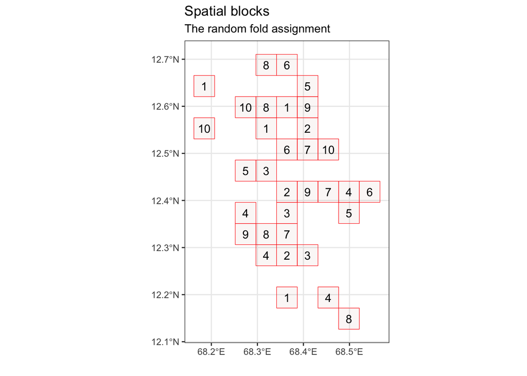

```
## The best folds was in iteration 31:
##    train test
## 1     37    3
## 2     36    4
## 3     35    5
## 4     35    5
## 5     37    3
## 6     37    3
## 7     36    4
## 8     35    5
## 9     35    5
## 10    37    3
```

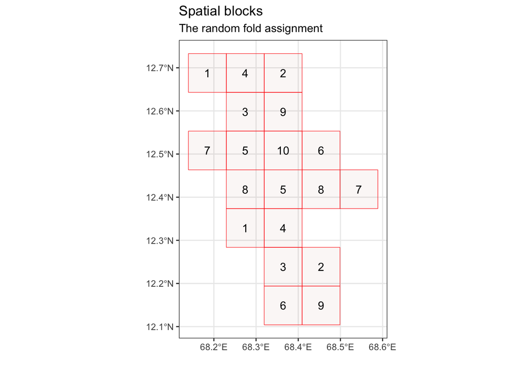

```
## The best folds was in iteration 39:
##    train test
## 1     35    5
## 2     36    4
## 3     38    2
## 4     38    2
## 5     32    8
## 6     32    8
## 7     39    1
## 8     37    3
## 9     37    3
## 10    36    4
```

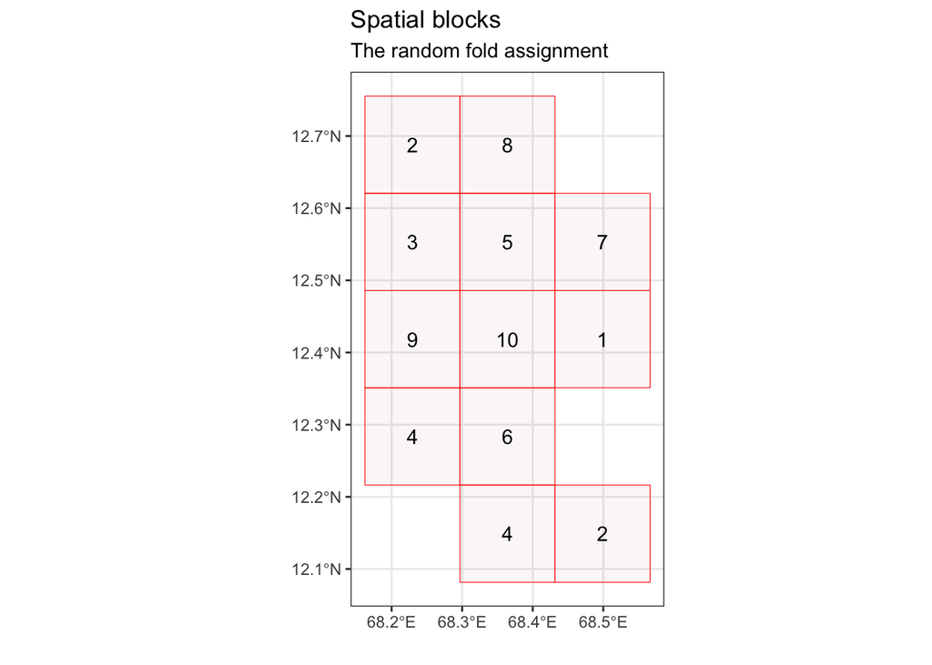

```
## The best folds was in iteration 1:
##    train test
## 1     30   10
## 2     39    1
## 3     35    5
## 4     38    2
## 5     39    1
## 6     28   12
## 7     38    2
## 8     37    3
## 9     37    3
## 10    39    1
```

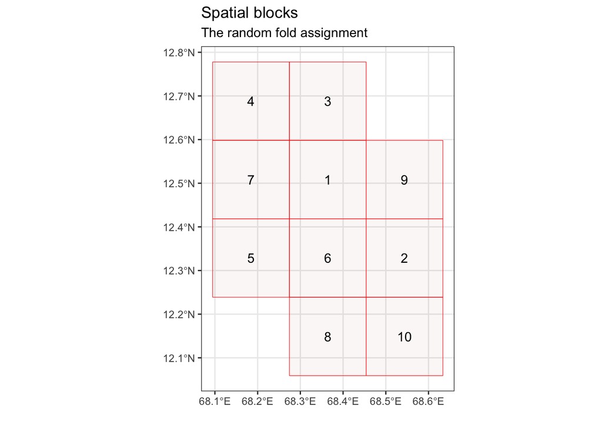

For pooled models, we may have more than 40 observations across different time points that we are performing cross-validation on. In the function written below, we create pooled folds by leaving out observations across all included time points for given clusters in the test set. This reduces dependence between the training and test sets (training set will not contain observations from the same cluster at a different time point).

```r
## Function - `get_pooled_folds`: takes folds (origami format) for 40 clusters and returns folds for pooled analysis -----
# folds_list (origami folds): folds to replicate in pooled form
# input_df (dataframe): pooled dataframe to create folds for
## -----------------------------------------------------------------------------------------------------------------------
get_pooled_folds <- function(folds_list, input_df){

  # pull fold vector -- vector with length of total n in folds, values represent test set
  temp_foldvec <- origami::folds2foldvec(folds_list)

  # match cluster_id to test set that it is in
  temp_clu_fold <- clu_sf %>% st_drop_geometry() %>% mutate(test_set = temp_foldvec)

  # join to get new foldvec; same cluster ID always in same test set
  new_foldvec <- input_df %>% left_join(temp_clu_fold, by = "cluster_id") %>% pull(test_set)

  # use origami function to transform foldvec to folds
  new_folds <- lapply(
    1:length(folds_list),
    function(x) origami::fold_from_foldvec(v = x, folds = new_foldvec))

  return(new_folds)
}
```

Because our sample size is fairly small (40 communities), we also explore leave-one-out cross-validation.

```r
loo_folds_list <- origami::make_folds(n = clu_sf, V = 40)
```

### Feature selection using LASSO

Due to the large number of potential features and relatively small number of communities, LASSO was used to select candidate features for predictive models.

```r
## Function - `get_glmnet_results`: prepare data for pooled & lagged models -------------------
# input_df (dataframe): dataframe with outcome and exposure variables
# outcome_var (character): outcome variable name
# outcome_survey (numeric): survey month of outcome variable (-1 for pooled)
# input_lag (numeric): number of months of lag between exposure and outcome
# covariates (character): name of vector containing predictor variables to be assessed
# folds_list (character): name of folds list to use
# input_alpha (numeric): alpha to use for glmnet (1 = lasso, 0 = ridge, or mixture)
# returns list of 1) prepared dataframe and 2) list of predictor variables
## --------------------------------------------------------------------------------------------
get_glmnet_results <- function(input_df, outcome_var, outcome_survey, input_lag, covariates, folds_list, input_alpha){

  # prepare dataset and folds
  prepped_data <- get_prepared_df(input_df = input_df,
                                  outcome_survey = outcome_survey,
                                  input_lag = input_lag,
                                  outcome_var = outcome_var,
                                  covariates = covariates)
  prepped_df <- prepped_data[[1]]
  prepped_covariates <- prepped_data[[2]]

  temp_folds_list <- get_pooled_folds(folds_list = get(folds_list),
                                      input_df = prepped_df)

  # prepare data in `cv.glmnet` formats
  pos_var <- get_pos_var(outcome_var)
  tested_var <- get_tested_var(outcome_var)
  Y <- cbind(prepped_df[,pos_var], prepped_df[,tested_var]-prepped_df[,pos_var]) %>% as.matrix()
  X <- prepped_df %>% dplyr::select(all_of(prepped_covariates)) %>% as.matrix()

  # run built-in CV glmnet procedure
  # model result depends on folds, so no need for additional seed here
  # catch error or warning - most common error is not converging
  temp_model <- tryCatch({glmnet::cv.glmnet(x = X, y = Y,
                                            family = binomial("logit"),
                                            type.measure = "mse",
                                            nfolds = length(temp_folds_list),
                                            foldid = origami::folds2foldvec(temp_folds_list),
                                            alpha = input_alpha)},
                         error = function(cond) return(cond$message),
                         warning = function(cond) return(cond$message))

  # prep results
  if(is.character(temp_model)){
    ret <- data.frame(covariate = prepped_covariates,
                      coefficient = NA,
                      cv_mse = NA,
                      cv_lambda.min = NA,
                      error_or_warn = temp_model)
  } else {
    ret <- coef(temp_model, s = "lambda.min")[,1] %>%
      # data wrangling to translate sparse matrix to df of covariates and coefficient values
      bind_rows() %>% t() %>% as.data.frame() %>%
      rownames_to_column(var = "covariate") %>%
      rename(coefficient = V1) %>%
      # add mse and lambda.min
      mutate(cv_mse = temp_model$cvm[temp_model$index["min",]],
             cv_lambda.min = temp_model$lambda.min,
             error_or_warn = NA)
  }

  return(ret)
}

glmnet_grid <- expand.grid(covariates = c("all", "all_but_trach"),
                           folds_list = c("random_folds_list", "block_folds_list_15"),
                           input_alpha = c(0.5, 1), # LASSO, mixture (0.5) also included for comparison
                           stringsAsFactors = FALSE) %>%
  mutate(outcome_var = "prevalence_pcr") %>%
  # add possible lag/survey combinations
  crossing(expand.grid(outcome_survey = c(survey_list, -1), input_lag = survey_list) %>%
           filter(input_lag <= outcome_survey | outcome_survey == -1))

# approx runtime: 3 minutes on 4 cores
cv_glmnet_results <- pbmcapply::pbmclapply(
  split(glmnet_grid, 1:nrow(glmnet_grid)),
  function(x){
    do.call(get_glmnet_results, args = c(list(input_df = clu_random_0to5), as.list(x))) %>%
      mutate(x)
  }, mc.cores = 4) %>%
  bind_rows()
```

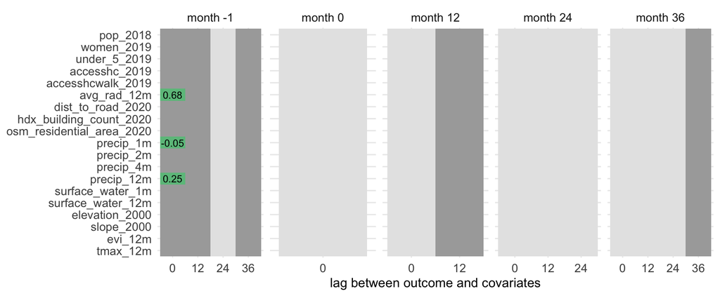

```r
# visualize glmnet results
cv_glmnet_results %>%
  filter(covariates == "all_but_trach",
         input_alpha == 1,
         folds_list == "block_folds_list_15") %>%
  filter(covariate != "(Intercept)") %>%
  mutate(covariate = str_remove(covariate, "_prepped"),
         covariate = factor(covariate, levels = rev(all_but_trach)),
         outcome_survey_label = paste("month", outcome_survey)) %>%
  mutate(coefficient_cat = case_when(coefficient == 0 ~ "0", coefficient != 0 ~ "!=0")) %>%
  ggplot(aes(x = as.factor(input_lag), y = covariate, fill = coefficient_cat)) +
  geom_tile() +
  geom_text(data = . %>% filter(coefficient_cat == "!=0"),
            aes(label = round(coefficient, digits = 2)),
            size = 3) +
  scale_fill_manual(values = c("!=0" = "#6cc08b", "0" = "darkgrey"), na.value = "grey90") +
  labs(x = "lag between outcome and covariates") +
  facet_wrap(.~outcome_survey_label, scales = "free_x", nrow = 1) +
  theme_minimal() +
  theme(legend.position = "none",
        axis.title.y = element_blank(),
        axis.text.y = element_text(size = 10),
        axis.text.x = element_text(size = 10),
        strip.text = element_text(size = 10))
```

GLMnet does not converge in many cases (light gray tiles), and results vary based on covariate list, alpha, and folds. We focus on covariates `avg_rad_12m`, `precip_12m`, and `precip_1m` identified by LASSO with 15x15km spatially-blocked folds in the pooled analysis with no lag. We later also dropped `precip_1m` as it did not substantially improve predictive performance. Models including `surface_water_12m` were also tested and had fairly similar predictive performance.

```r
glmnet_vars <- c("avg_rad_12m", "precip_12m", "precip_1m")
glmnet_and_trach <- c(glmnet_vars, trach_ind)

# restricted version
glmnet_vars_2 <- c("avg_rad_12m", "precip_12m")
glmnet_and_trach_2 <- c(glmnet_vars_2, trach_ind)
```

### Logistic prediction models

The code in this section runs logistic regression models with cross-validation across a range of covariate combinations.

```r
## Function - `cv_logistic`: function to fit logistic models to each CV fold -----
# based on example in `origami` vignette
# fold: current fold (in `origami` format)
# input_df (data frame): input dataset
# outcome_var (character): name of outcome variable
# covariates (character vector): list of covariates to include
# matern_var (character): matern covariate, if applicable
## --------------------------------------------------------------------------------
cv_logistic <- function(fold, input_df, outcome_var, covariates, matern_var){

  # split up data into training and validation sets
  train_data <- input_df[fold$training_set,]
  valid_data <- input_df[fold$validation_set,]

  # prepare formula for model
  temp_formula <- prep_binom_formula(outcome_var = outcome_var,
                                     covariates = covariates,
                                     matern_var = matern_var)

  # fit model
  temp_fit <- spaMM::fitme(formula = as.formula(temp_formula),
                           data = train_data,
                           family = binomial("logit"),
                           method = "ML") # ML is default

  # get predictions in validation set
  temp_preds <- predict(temp_fit,
                        type = "response",
                        newdata = valid_data)

  # outputs
  ret <- list(fold = rep(fold$v, nrow(valid_data)), #fold index
              index = fold$validation_set, #cluster row index
              obs = valid_data %>% pull(all_of(outcome_var)), #obs outcomes in validation set
              preds = as.vector(temp_preds), #predicted outcomes in validation set
              formula = temp_formula)

  return(ret)
}

## Function - `get_cv_logistic_summary`: convenience function to get summary statistics for each model fit -----
# obs (numeric vector): observed values
# preds (numeric vector): model predicted values
# conf (numeric): desired confidence level for CI
# returns mean squared error (MSE), root MSE, R^2 and influence-function-based CI
## --------------------------------------------------------------------------------
get_cv_logistic_summary <- function(obs, preds, conf){

  mse <- mean((obs - preds)^2)
  rmse <- sqrt(mse)
  r2_ci <- get_r2_ci(obs = obs, pred = preds, conf = conf)

  n <- length(obs)

  return(data.frame(mse = mse, rmse = rmse, n = n) %>%
           mutate(r2_ci %>% as.list() %>% as.data.frame())) # some data wrangling needed to transform get_r2_ci output to df
}
```

```r
## set up Matern covariates
spaMM_matern <- "Matern(1| lat + lon)"
spaMM_matern_time <- "Matern(1| lat + lon + survey)"

# create covariate combinations including survey
sero_and_time <- c("prevalence_sero", "survey")
glmnet_and_trach_time <- c(glmnet_and_trach, "survey")
glmnet_and_trach_2_time <- c(glmnet_and_trach_2, "survey")

## create parameter combinations to iterate over
# ALL: main manuscript + supporting information
# cv_logistic_grid <- expand.grid(
#   covariates = c("pcr_only", "sero_only",
#                  "clin_only", "trach_ind",
#                  "glmnet_vars_2", "glmnet_and_trach_2",
#                  "sero_and_time", "glmnet_and_trach_2_time"),
#   matern_var = c(NA, spaMM_matern, spaMM_matern_time),
#   folds_name = c("random_folds_list", "loo_folds_list",
#                  "block_folds_list_5", "block_folds_list_10",
#                  "block_folds_list_15", "block_folds_list_20"),
#   stringsAsFactors = FALSE) %>%
#   mutate(outcome_var = "prevalence_pcr") %>%
#   # add possible lag/survey combinations
#   crossing(expand.grid(outcome_survey = c(survey_list, -1), input_lag = survey_list) %>%
#            filter(input_lag <= outcome_survey | outcome_survey == -1)) %>%
#   # filter some combinations to reduce runtime
#   filter((matern_var == spaMM_matern_time & covariates %in% c("sero_only", "glmnet_and_trach_2")) |
#            is.na(matern_var) | matern_var != spaMM_matern_time) %>%
#   # survey covariate only contributes when including covariates from >1 survey
#   filter(!(covariates %in% c("sero_and_time", "glmnet_and_trach_2_time") & (outcome_survey != -1 | input_lag == 36))) %>%
#   # add index so that later can access results with best parameters in results list
#   mutate(param_index = row_number()) %>%
#   as.data.frame()

# SHORT: main manuscript only
cv_logistic_grid <- expand.grid(
  covariates = c("pcr_only", "sero_only",
                 "clin_only", "trach_ind",
                 "glmnet_vars_2", "glmnet_and_trach_2"),
  matern_var = c(NA, spaMM_matern),
  folds_name = c("block_folds_list_15"),
  stringsAsFactors = FALSE) %>%
  mutate(outcome_var = "prevalence_pcr") %>%
  # add possible lag/survey combinations
  crossing(expand.grid(outcome_survey = c(36), input_lag = survey_list) %>%
           filter(input_lag <= outcome_survey | outcome_survey == -1)) %>%
  # filter some combinations to reduce runtime
  filter((matern_var == spaMM_matern & covariates %in% c("sero_only", "glmnet_and_trach_2")) |
           is.na(matern_var)) %>%
  # survey covariate only contributes when including covariates from >1 survey
  filter(!(covariates %in% c("sero_and_time", "glmnet_and_trach_2_time") & (outcome_survey != -1 | input_lag == 36))) %>%
  # add index so that later can access results with best parameters in results list
  mutate(param_index = row_number()) %>%
  as.data.frame()

## iterate through parameters
# approx runtime for all on 4 cores: 60 minutes
cv_logistic_results <- pbmcapply::pbmclapply(
  1:nrow(cv_logistic_grid),
  function(x){
    # prepare data and covariate name list
    prepped_data <- get_prepared_df(input_df = clu_random_0to5,
                                    outcome_survey = cv_logistic_grid[x,"outcome_survey"],
                                    input_lag = cv_logistic_grid[x,"input_lag"],
                                    outcome_var = cv_logistic_grid[x,"outcome_var"],
                                    covariates = cv_logistic_grid[x,"covariates"])

    # prepare folds
    prepped_folds <- get_pooled_folds(folds_list = get(cv_logistic_grid[x, "folds_name"]),
                                      input_df = prepped_data[[1]])

    # perform cross-validation
    cross_validate(cv_fun = cv_logistic,
                   folds = prepped_folds,
                   input_df = prepped_data[[1]],
                   outcome_var = cv_logistic_grid[x,"outcome_var"],
                   covariates = prepped_data[[2]],
                   matern_var = cv_logistic_grid[x, "matern_var"])
    },
mc.cores = 4 # set number of cores for parallel processing
)

## summarize data
cv_logistic_summary <- lapply(
  1:length(cv_logistic_results),
  function(x){
    get_cv_logistic_summary(obs = cv_logistic_results[[x]]$obs, preds = cv_logistic_results[[x]]$preds, conf = 0.95) %>%
      mutate(cv_logistic_grid[x,]) %>%
      mutate(formula = cv_logistic_results[[x]]$formula[1])}) %>%
  bind_rows()
```

### Stacked ensemble prediction

Documentation for `sl3` can be found [here](https://tlverse.org/sl3/reference/index.html). Since our outcomes are proportional, `outcome_type` must be specified as quasibinomial for certain learners (e.g. glm). Coefficient estimates are same as binomial, but standard errors differ; this should not affect our analysis as we are not conducting inference on individual coefficients.

```r
## Function - `fit_superlearner`: fit stacked ensemble using `sl3` package -----
# input_df (dataframe): input data frame
# outcome_var (character): name of outcome variable
# outcome_survey (numeric): month of outcome survey
# input_lag (numeric): lag time (in months) between outcome and predictors
# covariates (character): name of covariate list
# folds_name (character): name of folds to be used for CV
# sl_method (character): desired superlearner method (glm, nnls, nnls-convex, spaMM, or spaMM-matern)
# returns results (either summary or full CV predictions) from stacked ensemble
# note that this function is difficult to replicate exactly with seeds
## -----------------------------------------------------------------------------
fit_superlearner <- function(input_df, outcome_var, outcome_survey, input_lag, covariates, folds_name, sl_method){

  ## prepare data -----
  prepped_data <- get_prepared_df(input_df = input_df,
                                  outcome_survey = outcome_survey,
                                  input_lag = input_lag,
                                  outcome_var = outcome_var,
                                  covariates = covariates)
  prepped_df <- prepped_data[[1]]
  prepped_covariates <- prepped_data[[2]]

  prepped_folds <- get_pooled_folds(folds_list = get(folds_name),
                                    input_df = prepped_df)

  pos_var <- paste0("n_pos_", str_split(outcome_var, "_")[[1]][2])
  tested_var <- paste0("n_tested_", str_split(outcome_var, "_")[[1]][2])

  # define learning task
  learner_task <- make_sl3_Task(data = prepped_df,
                                covariates = prepped_covariates,
                                outcome = outcome_var,
                                outcome_type = "quasibinomial",
                                folds = prepped_folds,
                                weights = tested_var)

  ## create stack of base learners -----
  # 1. logistic regression (glm)
  base_glm <- make_learner(Lrnr_glm)

  # 2. splines (gam)
  if(prepped_covariates[1] == 1){
    temp_gam_formula <- 1
  } else {
    temp_gam_formula <- paste(paste0("s(", prepped_covariates, ",k=3)"), collapse = "+")
  }
  full_gam_formula <- paste0(outcome_var, "~", temp_gam_formula)
  base_gam <- make_learner(Lrnr_gam,
                           outcome_type = "continuous",
                           method = "REML",
                           select = TRUE,
                           formula = full_gam_formula)

  # 3. multivariate adaptive regression spline - MARS (earth)
  base_earth <- make_learner(Lrnr_earth,
                             outcome_type = "continuous")

  # 4. random forest (randomForest)
  base_randomForest <- make_learner(Lrnr_randomForest)

  # 5. xgboost (xgboost)
  base_xgboost <- make_learner(Lrnr_xgboost)

  base_learner_list <- list(base_glm,
                            base_gam,
                            base_earth,
                            base_randomForest,
                            base_xgboost)

  ## initialize superlearner depending on desired model -----
  if (sl_method=="glm"){
    metalearner <- make_learner(Lrnr_glm)
  } else if (sl_method=="nnls"){
    metalearner <- make_learner(Lrnr_nnls)
  } else if (sl_method=="nnls-convex"){
    metalearner <- make_learner(Lrnr_nnls, convex=TRUE)
  } else if (sl_method=="spaMM"){
    metalearner <- make_learner(Lrnr_spaMM,
                                outcome_formula = paste0("cbind(", pos_var, ",", tested_var, "-", pos_var, ")"),
                                outcome_covariates = c(pos_var, tested_var),
                                matern_covariates = c(),
                                outcome_type = "binomial",
                                method = "ML") # default is ML
  } else if (sl_method=="spaMM-matern"){
    metalearner <- make_learner(Lrnr_spaMM,
                                outcome_formula = paste0("cbind(", pos_var, ",", tested_var, "-", pos_var, ")"),
                                outcome_covariates = c(pos_var, tested_var),
                                matern_covariates = c("lat", "lon"),
                                outcome_type = "binomial",
                                method = "ML") # default is ML
  }

  ## fit cross-validated superlearner -----
  # fit "manually" to pull out predicted values
  # alternative would be to use `CV_lrnr_sl` to extract loss
  cv_sl <- make_learner(learner_class = Lrnr_cv,
                        learner = Lrnr_sl$new(learners = base_learner_list,
                                              metalearner = metalearner),
                        full_fit = FALSE)
  cv_sl_fit <- cv_sl$train(learner_task)
  sl_risk <- cv_sl_fit$cv_risk(loss_squared_error)

  ## get results -----
  # get R^2 and CI for metalearner
  unwt_obs <- prepped_df[, outcome_var] %>% pull()
  unwt_pred <- cv_sl_fit$predict()
  unwt_mse <- mean((unwt_obs-unwt_pred)^2)
  sl_r2_ci <- get_r2_ci(obs = unwt_obs,
                        pred = unwt_pred,
                        conf = 0.95)

  ret_summary <- c(sl_mean_risk = sl_risk$mean_risk, # MSE weighted by input weights
                   sl_rmse = sqrt(sl_risk$mean_risk),
                   sl_SE_risk = sl_risk$SE_risk,
                   unwt_mse = unwt_mse, # unweighted values analogous to R^2 calculated for logistic
                   sl_r2_ci)

  ret_pred <- data.frame(cluster_id = prepped_df[, "cluster_id"] %>% pull(),
                         obs = unwt_obs,
                         pred = unwt_pred,
                         outcome_var = outcome_var,
                         outcome_survey = outcome_survey,
                         input_lag = input_lag,
                         covariates = covariates,
                         folds_name = folds_name,
                         sl_method = sl_method)

  ret <- list(summary = ret_summary,
              pred = ret_pred)

  return(ret)
}
```

```r
## create iterations for superlearner models
# ALL: main manuscript + supporting information
# sl_grid <- expand.grid(sl_method = c("glm", "nnls", "nnls-convex", "spaMM", "spaMM-matern"),
#                        folds_name = c("loo_folds_list", "random_folds_list",
#                                       "block_folds_list_5", "block_folds_list_10",
#                                       "block_folds_list_15", "block_folds_list_20"),
#                        stringsAsFactors = FALSE) %>%
#   # add possible lag/survey combinations
#   crossing(expand.grid(outcome_survey = c(survey_list, -1), input_lag = survey_list) %>%
#            filter(input_lag <= outcome_survey | outcome_survey == -1)) %>%
#   mutate(outcome_var = "prevalence_pcr",
#          covariates = "glmnet_and_trach_2") %>%
#   # limit to combinations required for figures since runtime is long
#   filter(folds_name != "loo_folds_list" |
#            (folds_name == "loo_folds_list" & outcome_survey == 36 & sl_method == "spaMM-matern")) %>%
#   filter(sl_method == "spaMM-matern" | (folds_name == "block_folds_list_15" & outcome_survey == 36)) %>%
#   filter(folds_name == "block_folds_list_15" | outcome_survey == 36) %>%
#   as.data.frame()

# SHORT: main manuscript only
sl_grid <- expand.grid(sl_method = c("spaMM-matern"),
                       folds_name = c("block_folds_list_15"),
                       stringsAsFactors = FALSE) %>%
  # add possible lag/survey combinations
  crossing(expand.grid(outcome_survey = c(36), input_lag = survey_list) %>%
           filter(input_lag <= outcome_survey | outcome_survey == -1)) %>%
  mutate(outcome_var = "prevalence_pcr",
         covariates = "glmnet_and_trach_2") %>%
  # limit to combinations required for figures since runtime is long
  filter(folds_name != "loo_folds_list" |
           (folds_name == "loo_folds_list" & outcome_survey == 36 & sl_method == "spaMM-matern")) %>%
  filter(sl_method == "spaMM-matern" | (folds_name == "block_folds_list_15" & outcome_survey == 36)) %>%
  filter(folds_name == "block_folds_list_15" | outcome_survey == 36) %>%
  as.data.frame()

## iterate through parameters
# approx runtime for all on 4 cores: 30 minutes
sl_results_all <- pbmcapply::pbmclapply(split(sl_grid, 1:nrow(sl_grid)),
                  function(x){
                    do.call(fit_superlearner, args = c(list(input_df = clu_random_0to5), as.list(x)))
                    }, mc.cores = 4)

sl_summary <- sl_results_all %>%
  purrr::map("summary") %>%
  bind_rows() %>%
  bind_cols(sl_grid)

sl_results <- sl_results_all %>%
  purrr::map("pred") %>%
  bind_rows()
```

### Save results

```r
if(save_results){
  write_rds(cv_logistic_results, file = here(output_path, paste0("cv_logistic_results_public", folds_seed, ".rds")))
  write_rds(cv_logistic_summary, file = here(output_path, paste0("cv_logistic_summary_public", folds_seed, ".rds")))
  write_rds(sl_results, file = here(output_path, paste0("sl_results_public", folds_seed, ".rds")))
  write_rds(sl_summary, file = here(output_path, paste0("sl_summary_public", folds_seed, ".rds")))
}
```